# Reconstruction by Linear Regression

W. Bauer

12/26/2014

### Summary

For a very simplified model of NIR emission and transport, recovery of detail is limited by the size of eigenvalues at spatial frequencies corresponding to the reciprocal of detail size. Simulations suggest that, noise-to-signal (amplitude) ratios will generally obscure spatial frequencies whose eigenvalues are one or two orders of magnitude smaller than the noise-to-signal ratio itself. Since eigenvalues decrease rapidly with spatial resolution, this would pose a fairly stringent requirement for measurement and detection.

### Reconstruction by linear regression

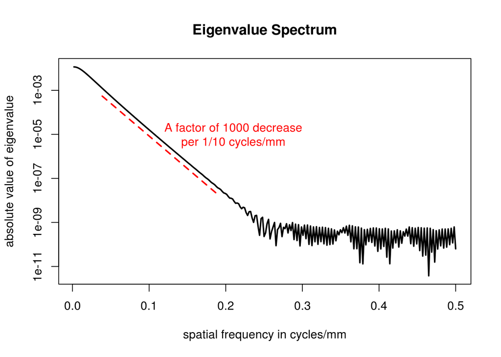

First consider a checkerboard pattern 50 mm in diameter with cell 10 mm on a side. Cells are alternately polarized (white,) and depolarized (red.) There are no emissions from the area colored green. (See the previous note for details.) With a noise-to-signal amplitude ratio one order of magnitude greater than the eigenvalue at spatial frequency 1/10 cycles/mm, the checkerboard pattern is discernible.

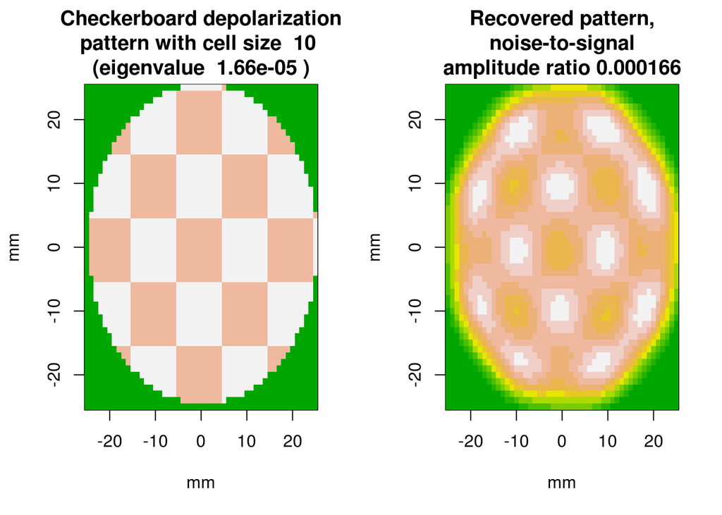

In this case, if the noise-to-signal ratio is two orders of magnitude above the appropriate eigenvalue, the checkerboard is not discernible.

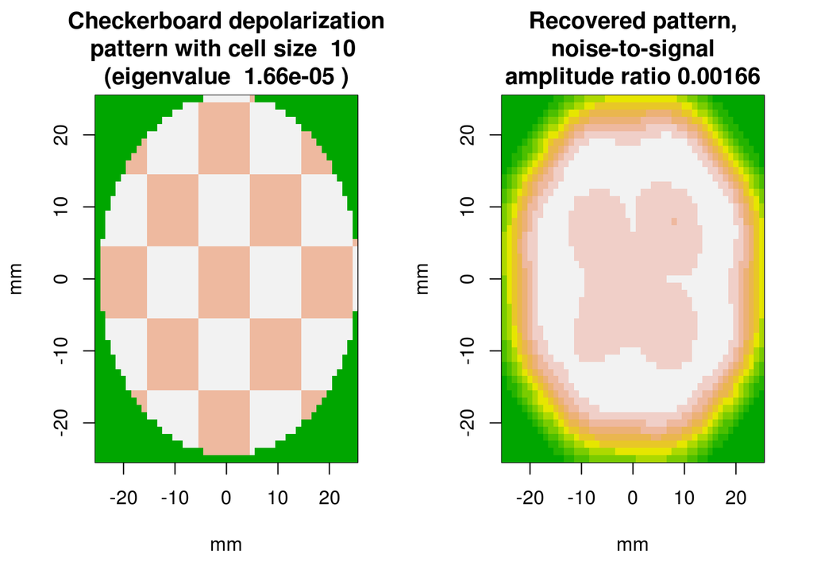

At 4 mm resolution, two orders of magnitude can be tolerated. However, the eigenvalue itself is extremely small. The noise-to-signal ratio’s reciprocal will almost surely exceed the number of photons per square mm reaching the scalp.

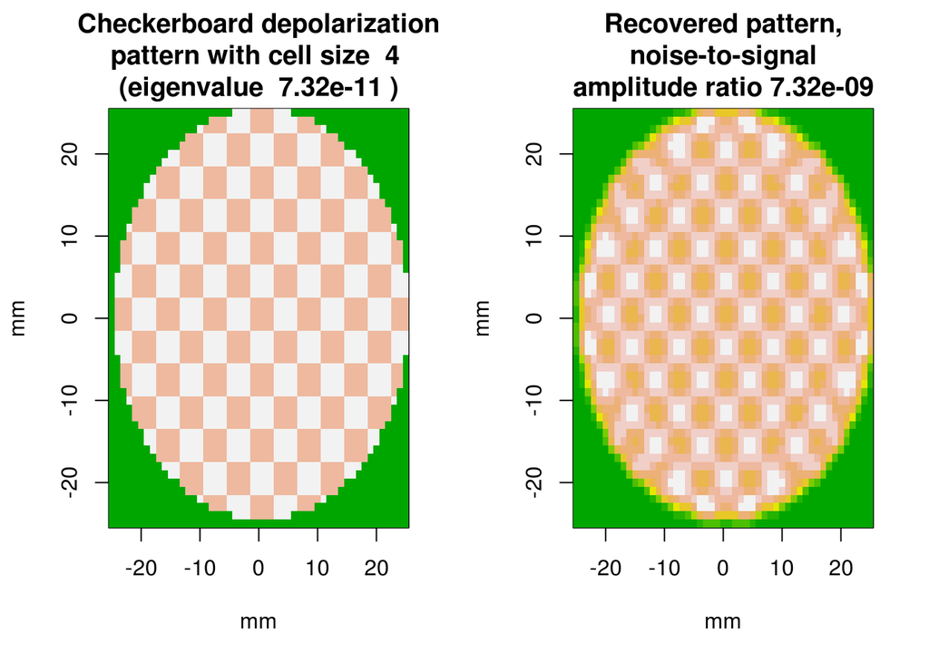

At 3 mm resolution the situation is similar.

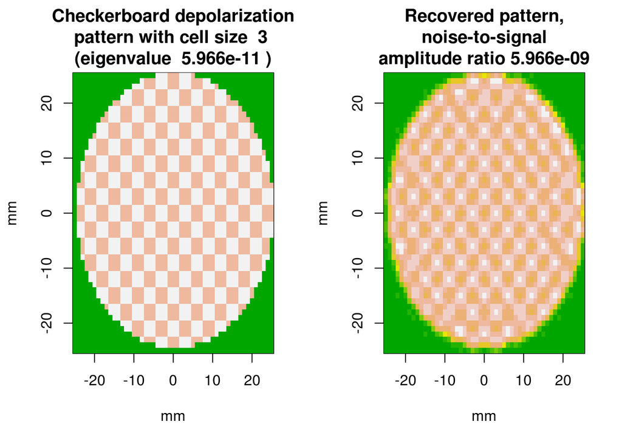

download Rmd which includes source code for computations